# Darkblotched Rockfish

*Sebastes crameri*

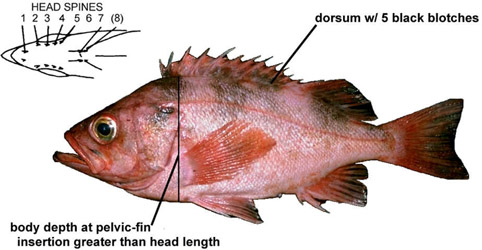

**Body color:** Reddish w/ five discrete black blotches on back, extending across lateral line.

**Peritoneum color:** dark **Shape between eyes:** convex

**Counts:** D:XII-XIII,12-15, Ar:5-7, P1:18-20, GR:29-34, LLp:40-51, LLs:48-62, V:26

**Occurence:** Bering Sea - Southern California

**Depth:** 100-600 meters **Size:** 45 cm **Species code:** 30170

**Similar species:**

- *Sharpchin rockfish* - symphyseal knob prominent; edge of operculum smooth (1-2 spines in Darkblotched RF); anal spine 2 longer than 3; head spines stronger and count differs
- *Harlequin rockfish* - posterior 2/3 of lateral line clear; dorsal fin blackish; anal spine 2 longer than 3; head spines stronger and count differs
- *Halfbanded rockfish* - body pink w/ 2 prominent blotches over lateral line; head spines weaker and count differs; body slender; anal spine 2 longer than 3
- *Pacific Ocean Perch* - dorsal blotches do not extend below lateral line; symphyseal knob elongate, sharp; head spines weaker and count typically differs
- *Yellowmouth rockfish* - yellow blotches inside mouth; dorsal blotches diffuse and do not extend below lateral line; head spines stronger and count differs

Back to Group

**Corrections:** If you see mistakes or want to suggest changes, please create an [issue](https://github.com/zoyafuso-NOAA/RACE_Survey_App/issues) on the source repository or

*reach out to Liz Dawson (Liz.Dawson AT noaa.gov).*